# Airline Delay Causes Dataset

## by Yasmin Shaaban

## Investigation Overview

In this investigation, I wanted to look at the number of flights within years 2019 and 2020 compare them to see the effect of COVID and the causes of delays that could be used to influence number of flights, which carrier that is used more . The main causes are weather , security and National Aviation system.

## Dataset Overview

The data consisted of attributes of approximately 30803 of flights . The attributes included the number of flights delayed to weather , Natianal Aviation System , security also total number of flights arrived , as well as additional measurements such as airport name and carrier name. 2225 data points were removed from the analysis due to inconsistencies or missing information.

## (Visualization 1)

### Distribution of number of arrived in the airport

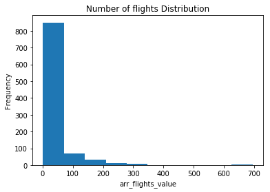

```python
#Histogram of number of flights
df_clean['arr_flights'].value_counts().plot(kind='hist')
plt.xlabel("arr_flights_value")
plt.title('Number of flights Distribution')
plt.show()
```

## (Visualization 2)

### Bar plot to show counts of airline carriers used

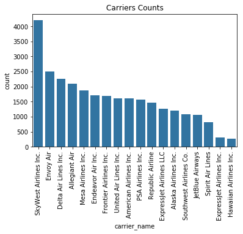

```python
#Carrier bar chart
base_color=sb.color_palette()[0]
carrier_order = df_clean['carrier_name'].value_counts().index
sb.countplot(data=df_clean,x='carrier_name',color=base_color,order=carrier_order)
plt.title("Carriers Counts")
plt.xticks(rotation = 90)
plt.show()
```

## (Visualization 3)

### Violin plot between year and number of flights

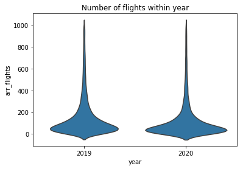

```python
#Violin plot between year and number of flights
sb.violinplot(data=df_clean,x='year',y='arr_flights',color=base_color,inner=None)
plt.title("Number of flights within year")
plt.show()
```

### Visualization 4

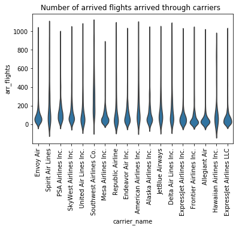

```python
yticks=np.arange(0,1000+200,200)
sb.violinplot(data=df_clean,x='carrier_name',y='arr_flights',color=base_color,inner=None)
plt.title("Number of arrived flights arrived through carriers  ")
plt.xticks(rotation = 90)
plt.yticks(yticks)
plt.show()
```

### Visualization 5

### Scatter plot which shows the relation between number of flights with respect to number of flights delayed due to weather in 2019 and 2020 year

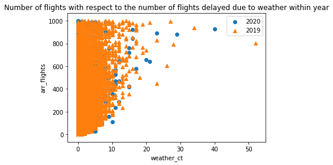

```python
year_markers = [[2020, 'o'],
               [2019, '^']]

for year, marker in year_markers:
    df_temp = df_clean[df_clean['year'] ==year ]
    plt.scatter(data = df_temp, x = ' weather_ct', y = 'arr_flights', marker = marker)
plt.legend(['2020','2019'])
plt.title('Number of flights with respect to the number of flights delayed due to weather within year')
plt.xlabel('weather_ct')
plt.ylabel('arr_flights')
plt.show()
```